# 1_Scatterplots_Hisograms_Barplots

## Exercise 3

Using `diamonds`, create a histogram for the variable `price` separating by `cut` and `clarity` using `facet_wrap()`. The expected output is shown below:

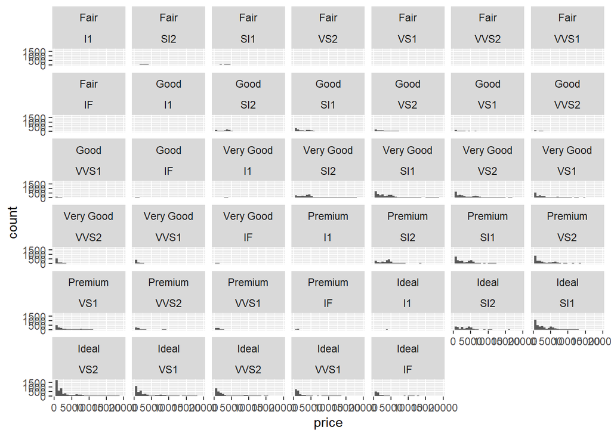

```r
ggplot(diamonds, aes(x = price)) +
  geom_histogram() +
  facet_wrap(c("cut","clarity"))
```

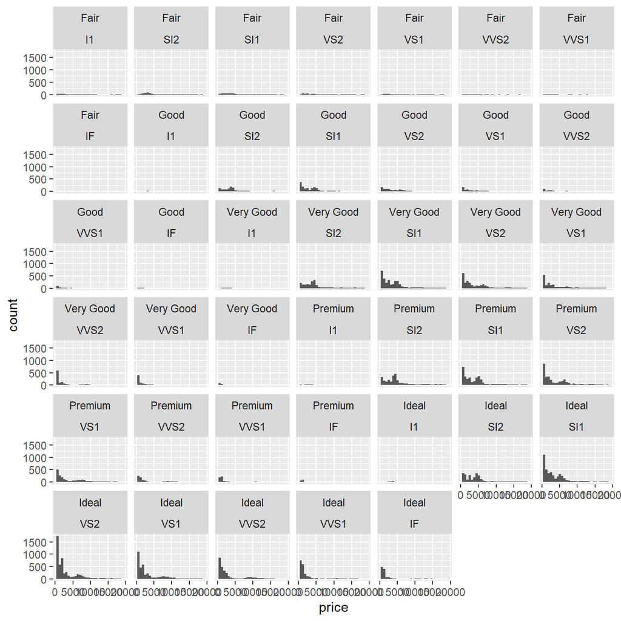

```r
# The output of the previous graph is masked because there are two many
# combinations of the categorical varaibles.
# Let us increase the size of the graph so that we can actually see something
# (code for increasing size not included).
ggplot(diamonds, aes(x = price)) +
  geom_histogram() +
  facet_wrap(c("cut","clarity"))
```

## Exercise 4

Using `diamonds`, create a histogram for the variable `price` separating by `clarity` (row-wise) and `cut` (column-wise) using `facet_grid()`. The expected output is shown below:

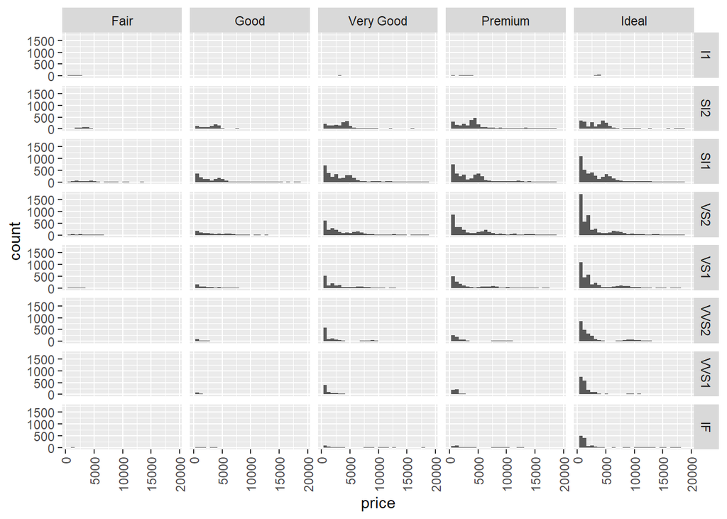

```r
# The output of the previous graph is masked because there are two many
# combinations of the categorical varaibles.
# Let us increase the size of the graph so that we can actually see something
ggplot(diamonds, aes(x = price)) +
  geom_histogram() +
  facet_grid(clarity~cut) +
  theme(axis.text.x = element_text(angle = 90, vjust = 0.5, hjust=1))
```

## `after_stat()` - histogram of relative frequencies

A histogram is by default built with the absolute frequencies, that is, with the total number of observations within each of the bins of the histogram.

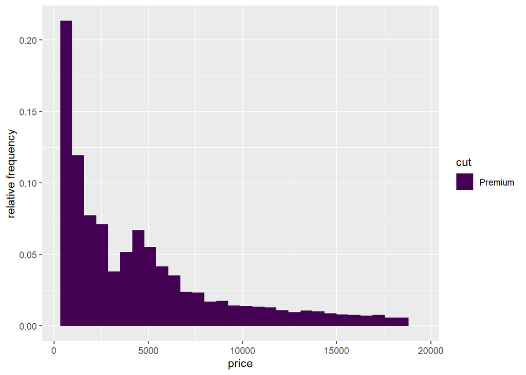

```r
ggplot(data = diamonds %>% filter(cut == "Premium"), aes(x = price, fill = cut)) +
    geom_histogram(aes(y = after_stat(count / sum(count)))) +
    labs(y = "relative frequency")
```

# Barplots

## Basic barplot

A barplot contains:

- a categorical/discrete variable in the x-axis
- absolute frequencies in the y-axis.

Let us use a `group_by()` to check the number of diamonds in each `color` category:

```r
diamonds %>%
  group_by(color) %>%
  summarize(
    n = n()
  )
```

```
# A tibble: 7 × 2
  color     n
  <ord> <int>
1 D      6775
2 E      9797
3 F      9542
4 G     11292
5 H      8304
6 I      5422
7 J      2808
```

We may obtain a graphical representation of this using a bar plot with the following code (output printed further down below):

```r
ggplot(diamonds, aes(x = color)) +
  geom_bar()
```

**By default geom_bar() uses the argument `stat = "count"`**. This is the default, unless we override it (see later section on `stat = "identity"`) and it does the following:

1. Counts the number of rows corresponding to each value of the categorical variable x, in this case `color`.
2. Prints a bar indicating that row count for each category (for each value of `x`). That is why we do not need to specify any variable `y`, the count is the varible `y`.

Further down below we clarify how to override this behavior using `stat = "identity"`. Let us now run the code above to see the output:

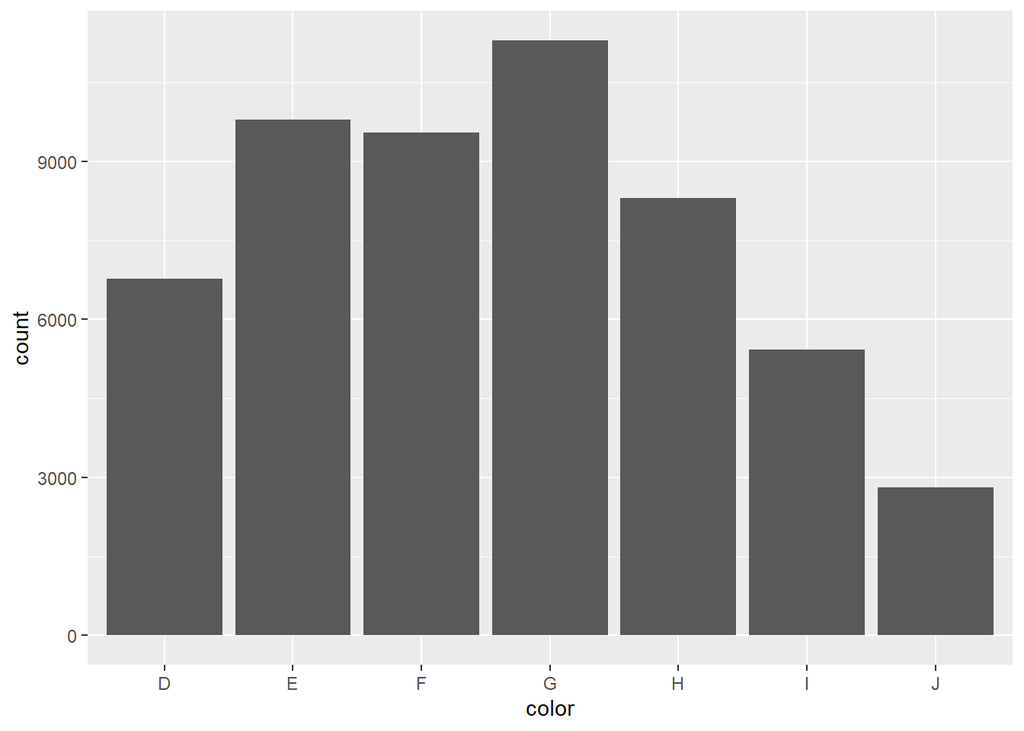

```r
ggplot(diamonds, aes(x = color)) +
  geom_bar()
```